# Randomized Complete Block Design (RCBD)

Controlling Heterogeneity to Increase Precision

Dr. Samuel B Fernandes

2026-01-01

## Learning Objectives

By the end of this lecture, you will be able to:

- Explain **why and when** to use blocking to control heterogeneity
- Design and randomize a **Randomized Complete Block Design (RCBD)**
- Analyze RCBD models
- Interpret block and treatment effects from ANOVA tables

# Part 1: Why Block?

## The Challenge: Hidden Variation

**The Problem:** Even within a single experiment, **experimental units are not identical**.

**Common sources of heterogeneity in agricultural research:**

- **Field trials:** Soil texture gradients, drainage patterns, fertility zones, edge effects
- **Greenhouse:** Bench position (light, temperature), proximity to doors/vents
- **Orchards:** Tree age, row position, rootstock variation
- **Animal studies:** Litter, age, initial weight, genetic background
- **Time effects:** Planting date, harvest day, processing batch, weather conditions

## Visual: The Problem with CRD

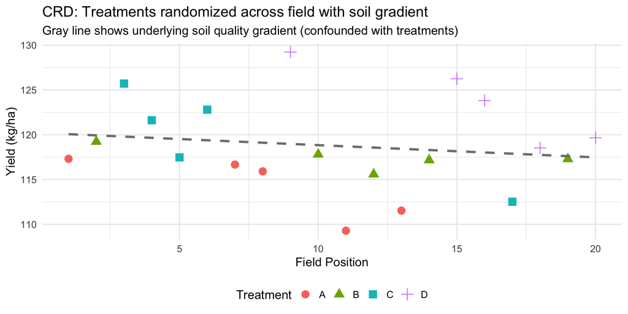

Figure 1: CRD with hidden gradient: treatments randomly assigned across heterogeneous field

```r
library(ggplot2)
library(dplyr)

set.seed(2026)
field_gradient <- data.frame(
    plot = 1:20,
    position = 1:20,
    treatment = sample(rep(c("A", "B", "C", "D"), each = 5)),
    soil_quality = seq(10, 5, length.out = 20) # Gradient from good to poor
) |>
    mutate(
        yield_base = 100 + soil_quality * 2,
        treatment_effect = case_when(
            treatment == "A" ~ 0,
            treatment == "B" ~ 3,
            treatment == "C" ~ 6,
            TRUE ~ 10
        ),
        yield = yield_base + treatment_effect + rnorm(20, 0, 3)
    )

ggplot(field_gradient, aes(x = position, y = yield, color = treatment, shape = treatment)) +
    geom_point(size = 4) +
    geom_smooth(aes(group = 1), method = "lm", se = FALSE, color = "gray50", linetype = "dashed") +
    labs(
        title = "CRD: Treatments randomized across field with soil gradient",
        subtitle = "Gray line shows underlying soil quality gradient (confounded with treatments)",
        x = "Field Position", y = "Yield (kg/ha)", color = "Treatment", shape = "Treatment"
    ) +
    theme_minimal(base_size = 14) +
    theme(legend.position = "bottom")
```

**Issue:** Treatments at different positions experience different soil conditions → inflated error variance

## The Solution: Blocking

**Key Idea:** **Group similar experimental units into blocks**; randomize treatments **within each block**.

**Benefits of Blocking:**

- Removes **known sources of variation** from error term
- **Smaller MS_Error** → more powerful F-tests
- **Fair comparison** of treatments (each block gets all treatments)
- **Increased precision** without increasing sample size

**When to Block:**

✅ Block when you can **identify and group** similar experimental units **before** the experiment

✅ Block on factors you’re **not interested in testing** (nuisance factors)

❌ Don’t block on factors you want to compare (those are treatments!)

## Visual: RCBD Solution

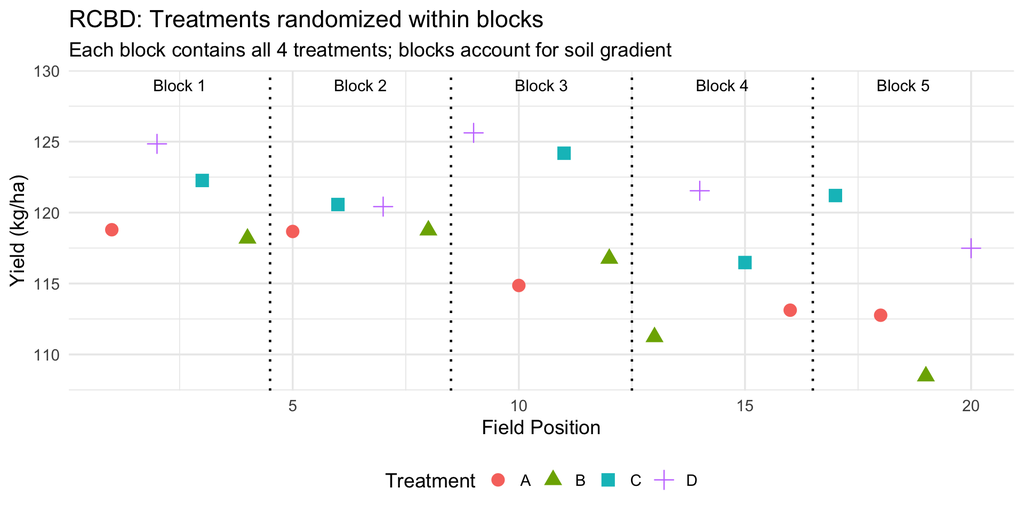

Figure 2: RCBD: Field divided into blocks; treatments randomized within each block

```r
set.seed(2026)
field_rcbd <- data.frame(
    block = rep(1:5, each = 4),
    position = rep(c(1, 2, 3, 4), times = 5)
) |>
    group_by(block) |>
    mutate(treatment = sample(c("A", "B", "C", "D"))) |>
    ungroup() |>
    mutate(
        field_position = (block - 1) * 4 + position,
        soil_quality = seq(10, 5, length.out = 20)[field_position],
        yield_base = 100 + soil_quality * 2,
        treatment_effect = case_when(
            treatment == "A" ~ 0,
            treatment == "B" ~ 3,
            treatment == "C" ~ 6,
            TRUE ~ 10
        ),
        yield = yield_base + treatment_effect + rnorm(20, 0, 3),
        block = factor(block)
    )

ggplot(field_rcbd, aes(x = field_position, y = yield, color = treatment, shape = treatment)) +
    geom_point(size = 4) +
    geom_vline(xintercept = c(4.5, 8.5, 12.5, 16.5), linetype = "dotted", color = "black", linewidth = 0.8) +
    annotate("text",
        x = c(2.5, 6.5, 10.5, 14.5, 18.5), y = 129,
        label = paste("Block", 1:5), color = "black", size = 4
    ) +
    labs(
        title = "RCBD: Treatments randomized within blocks",
        subtitle = "Each block contains all 4 treatments; blocks account for soil gradient",
        x = "Field Position", y = "Yield (kg/ha)", color = "Treatment", shape = "Treatment"
    ) +
    theme_minimal(base_size = 14) +
    theme(legend.position = "bottom")
```

**Result:** Block-to-block variation removed from error term; treatments compared fairly within blocks

# RCBD Model & Structure

## The RCBD Statistical Model

$$y_{ij} = \mu + \beta_j + \tau_i + \epsilon_{ij}$$

Where:

- $y_{ij}$ = response for treatment $i$ in block $j$
- $\mu$ = overall mean
- $\beta_j$ = effect of block $j$ (removes known heterogeneity)
- $\tau_i$ = effect of treatment $i$ (what we want to test!)
- $\epsilon_{ij} \sim N(0, \sigma^2)$ = random error (within-block variability)

**Key assumption:** **Additivity** — block and treatment effects are additive (no interaction)

**Additivity means:** The effect of a treatment is the same across all blocks. Block effects shift all treatments up or down equally.

## ANOVA Table: CRD vs RCBD

**CRD (One-Way ANOVA)**

| Source | df | SS | MS | F |
| --- | --- | --- | --- | --- |
| Treatment | $t-1$ | SS_Trt | MS_Trt | F_Trt |
| **Error** | **$t(r-1)$** | **SS_E** | **MS_E** |  |
| Total | $tr-1$ | SS_Total |  |  |

**Error includes:**

- Within-treatment variation
- **+ Block-to-block variation** ❌

**RCBD**

| Source | df | SS | MS | F |
| --- | --- | --- | --- | --- |
| **Block** | **$b-1$** | **SS_Block** | **MS_Block** | **F_Block** |
| Treatment | $t-1$ | SS_Trt | MS_Trt | F_Trt |
| **Error** | **$(b-1)(t-1)$** | **SS_E** | **MS_E** |  |
| Total | $bt-1$ | SS_Total |  |  |

**Error includes:**

- Within-block variation only ✅
- Block variation **removed**!

**Result:** $MS_{Error(RCBD)} < MS_{Error(CRD)}$ → more powerful tests

## Assumptions for RCBD

Same as CRD, plus one more:

1. **Normality:** Errors $\epsilon_{ij}$ are normally distributed
2. **Homogeneity of variance:** Equal variance across treatment-block combinations
3. **Independence:** Observations are independent (proper randomization)
4. **Additivity (NEW!):** No block × treatment interaction

**Caution**

**Important:** If interaction exists (non-additivity), we need a mixed model or analyze blocks separately! Or multiple reps/block to test interaction.

we can check it with `asbio::tukey.add.test()`!

# Part 2: Examples & Applications

## Example 1: Flower Vase Experiment

**Research Question:** Does the liquid in a vase affect how long cut flowers last?

**Experimental Design:**

- **Treatments (4):** Tap water, Sugar water, Carbonated water, 7-Up
- **Blocks (3):** Flower species (Rose, Daisy, Tulip)
- **Response:** Days until flower wilts
- **Why block?** Different species have different baseline vase life

Each species (block) gets all 4 liquid treatments → **complete** block design

## Flower Vase: Design & Randomization )

By hand or using the FielDHub Shiny app.

```r
set.seed(2026)
trt_levels <- c("Tap", "Sugar", "Carbonated", "7-Up")
b1 <- sample(trt_levels,4)
b2 <- sample(trt_levels,4)
b3 <- sample(trt_levels,4)
block <- factor( rep(c("daisy", "rose", "tulip"), each=4))
flower_plan <- data.frame(TypeFlower = block, FlowerNumber = 1:12, treatment = c(b1, b2, b3))
#write_csv(flower_plan, file = "RCBPlan.csv")
```

## Flower Vase: Simulated Data & Analysis

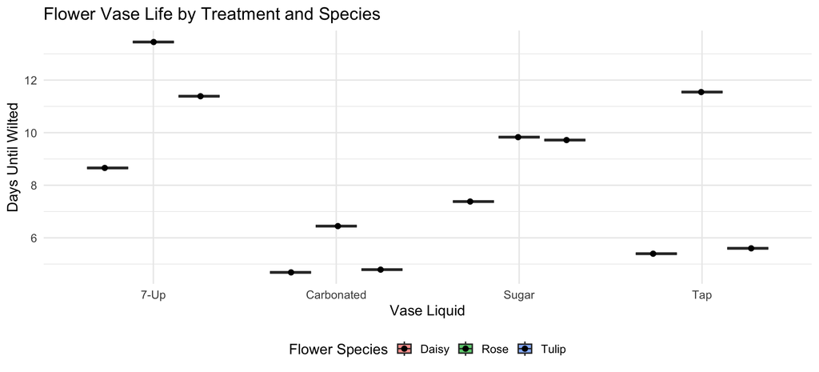

```r
library(ggplot2)
library(car)
library(emmeans)

# Simulate realistic data
flower_data <- flower_plan |>
    mutate(
        # Add species labels based on block
        species = c("Rose", "Daisy", "Tulip")[block],
        # Species baseline effect
        species_effect = case_when(
            species == "Rose" ~ 3,
            species == "Daisy" ~ -1,
            species == "Tulip" ~ 0,
            TRUE ~ 0
        ),
        # Treatment effect
        trt_effect = case_when(
            treatment == "Tap" ~ 0,
            treatment == "Sugar" ~ 3,
            treatment == "Carbonated" ~ 1,
            treatment == "7-Up" ~ 4,
            TRUE ~ 0
        ),
        days_wilted = 7 + species_effect + trt_effect + rnorm(n(), 0, 1.5)
    )

# Visualize: Boxplot by treatment, colored by block
ggplot(flower_data, aes(x = treatment, y = days_wilted, fill = species)) +
    geom_boxplot(alpha = 0.7) +
    geom_point(position = position_jitterdodge(jitter.width = 0.1), size = 2) +
    labs(
        title = "Flower Vase Life by Treatment and Species",
        x = "Vase Liquid", y = "Days Until Wilted", fill = "Flower Species"
    ) +
    theme_minimal(base_size = 14) +
    theme(legend.position = "bottom")
```

## Flower Vase: ANOVA with Type III SS

**Critical:** Set contrasts **before** fitting the model for Type III SS!

```r
# Set sum-to-zero contrasts for Type III SS
options(contrasts = c("contr.sum", "contr.poly"))

# Fit RCBD model: y ~ block + treatment
model_flower <- lm(days_wilted ~ block + treatment, data = flower_data)

# Type III ANOVA (order-independent)
Anova(model_flower, type = "III")
```

```
#> Anova Table (Type III tests)
#>
#> Response: days_wilted
#>             Sum Sq Df  F value    Pr(>F)
#> (Intercept) 814.85  1 399.7067 1.016e-06 ***
#> block        29.50  2   7.2361   0.02517 *
#> treatment    54.69  3   8.9421   0.01241 *
#> Residuals    12.23  6
#> ---
#> Signif. codes:  0 '***' 0.001 '**' 0.01 '*' 0.05 '.' 0.1 ' ' 1
```

**Interpretation:**

- Block (species) effect: **p < 0.05** → species differ in baseline vase life
- Treatment effect: **p < 0.05** → liquid type affects vase life
- Use smaller MS_Error from RCBD (not from ignoring blocks!)

## Flower Vase: Model Diagnostics with easystats

```r
library(easystats)

# Check all assumptions at once
check_model(model_flower)
```

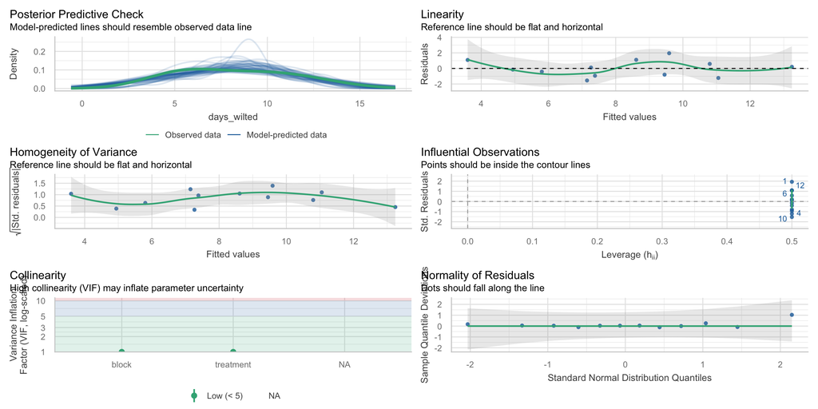

**easystats interpretation:**

- `check_model()` produces 6 diagnostic plots automatically
- Look for: normality (Q-Q plot), homogeneity (scale-location), outliers, influential points

## Flower Vase: Post-hoc Comparisons

```r
# Estimated marginal means by treatment
emm_flower <- emmeans(model_flower, ~treatment)

# Pairwise comparisons with Tukey adjustment
pairs(emm_flower, adjust = "tukey")
```

```
#>  contrast            estimate   SE df t.ratio p.value
#>  (7-Up) - Carbonated     5.86 1.17  6   5.025  0.0095
#>  (7-Up) - Sugar          2.19 1.17  6   1.877  0.3281
#>  (7-Up) - Tap            3.65 1.17  6   3.132  0.0735
#>  Carbonated - Sugar     -3.67 1.17  6  -3.148  0.0722
#>  Carbonated - Tap       -2.21 1.17  6  -1.893  0.3222
#>  Sugar - Tap             1.46 1.17  6   1.255  0.6191
#>
#> Results are averaged over the levels of: block
#> P value adjustment: tukey method for comparing a family of 4 estimates
```

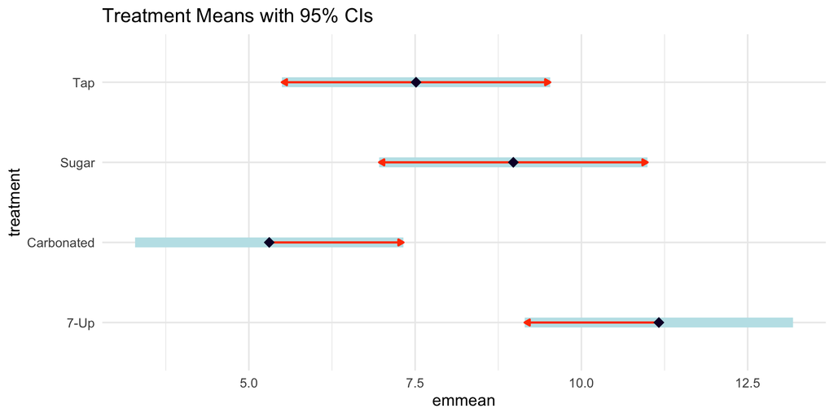

```r
# Visualize with confidence intervals
plot(emm_flower, comparisons = TRUE) +
    labs(title = "Treatment Means with 95% CIs") +
    theme_minimal(base_size = 14)
```

## Check Additivity with Interaction Plot

[figure not shown]

```r
# Interaction plot to check additivity assumption
ggplot(flower_data, aes(x = treatment, y = days_wilted, color = species, group = species)) +
    stat_summary(fun = mean, geom = "point", size = 3) +
    stat_summary(fun = mean, geom = "line", linewidth = 1) +
    labs(
        title = "Interaction Plot: Check for Additivity",
        subtitle = "Parallel lines indicate no block × treatment interaction (good!)",
        x = "Treatment", y = "Mean Days Until Wilted", color = "Species"
    ) +
    theme_minimal(base_size = 14) +
    theme(legend.position = "bottom")
```

# Example 3: Real Agricultural Data

## Example 3: Oats Yield Trial (agridat)

Using the classic **Yates oats dataset** from `agridat` package:

```r
library(agridat)
data(yates.oats)

# Examine structure
str(yates.oats)
```

```
#> 'data.frame':    72 obs. of  8 variables:
#>  $ row  : int  16 12 3 14 8 5 15 11 3 14 ...
#>  $ col  : int  3 4 3 1 2 2 4 4 4 2 ...
#>  $ yield: int  80 60 89 117 64 70 82 102 82 114 ...
#>  $ nitro: num  0 0 0 0 0 0 0.2 0.2 0.2 0.2 ...
#>  $ gen  : Factor w/ 3 levels "GoldenRain","Marvellous",..: 1 1 1 1 1 1 1 1 1 1 ...
#>  $ block: Factor w/ 6 levels "B1","B2","B3",..: 1 2 3 4 5 6 1 2 3 4 ...
#>  $ grain: num  20 15 22.2 29.2 16 ...
#>  $ straw: num  28 25 40.5 28.8 32 ...
```

```r
# Summary
head(yates.oats)
```

```
#>   row col yield nitro        gen block grain straw
#> 1  16   3    80     0 GoldenRain    B1 20.00 28.00
#> 2  12   4    60     0 GoldenRain    B2 15.00 25.00
#> 3   3   3    89     0 GoldenRain    B3 22.25 40.50
#> 4  14   1   117     0 GoldenRain    B4 29.25 28.75
#> 5   8   2    64     0 GoldenRain    B5 16.00 32.00
#> 6   5   2    70     0 GoldenRain    B6 17.50 27.25
```

**Study details:**

- **Treatments:** Nitrogen levels (0, 0.2, 0.4, 0.6 cwt/acre)
- **Blocks:** 6 blocks
- **Varieties:** 3 oat varieties (Golden Rain, Marvellous, Victory)
- **Response:** Grain yield

## Oats: Visualize Block & Treatment Structure

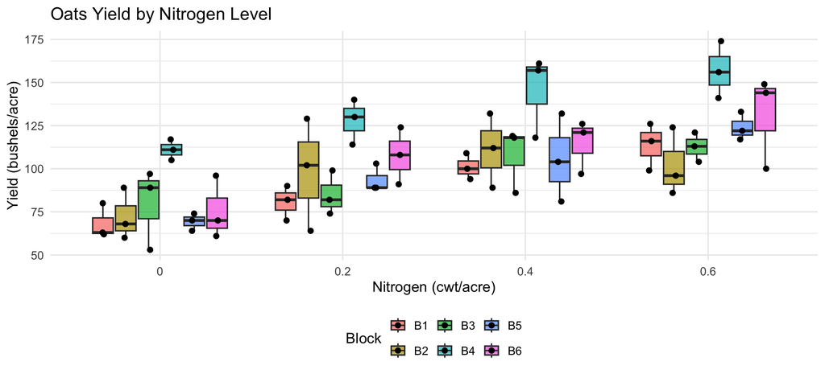

```r
# Focus on nitrogen effect within one variety
oats_subset <- yates.oats

ggplot(oats_subset, aes(x = factor(nitro), y = yield, fill = block)) +
    geom_boxplot(alpha = 0.7) +
    geom_point(position = position_jitterdodge(jitter.width = 0.1), size = 2) +
    labs(
        title = "Oats Yield by Nitrogen Level",
        x = "Nitrogen (cwt/acre)", y = "Yield (bushels/acre)", fill = "Block"
    ) +
    theme_minimal(base_size = 14) +
    theme(legend.position = "bottom")
```

## Oats: RCBD Analysis

```r
# Set contrasts
options(contrasts = c("contr.sum", "contr.poly"))

# Fit RCBD model (include variety as additional factor)
model_oats <- lm(yield ~ block + gen + factor(nitro), data = oats_subset)

# Type III ANOVA
Anova(model_oats, type = "III")
```

```
#> Anova Table (Type III tests)
#>
#> Response: yield
#>               Sum Sq Df   F value    Pr(>F)
#> (Intercept)   778336  1 3319.2914 < 2.2e-16 ***
#> block          15875  5   13.5403 6.906e-09 ***
#> gen             1786  2    3.8091   0.02762 *
#> factor(nitro)  20020  3   28.4598 1.239e-11 ***
#> Residuals      14304 61
#> ---
#> Signif. codes:  0 '***' 0.001 '**' 0.01 '*' 0.05 '.' 0.1 ' ' 1
```

```r
# Post-hoc for nitrogen effect
emm_oats <- emmeans(model_oats, ~nitro)
pairs(emm_oats, adjust = "tukey")
```

```
#>  contrast            estimate  SE df t.ratio p.value
#>  nitro0 - nitro0.2     -19.50 5.1 61  -3.820  0.0017
#>  nitro0 - nitro0.4     -34.83 5.1 61  -6.824  <.0001
#>  nitro0 - nitro0.6     -44.00 5.1 61  -8.620  <.0001
#>  nitro0.2 - nitro0.4   -15.33 5.1 61  -3.004  0.0197
#>  nitro0.2 - nitro0.6   -24.50 5.1 61  -4.800  0.0001
#>  nitro0.4 - nitro0.6    -9.17 5.1 61  -1.796  0.2852
#>
#> Results are averaged over the levels of: block, gen
#> P value adjustment: tukey method for comparing a family of 4 estimates
```

**Result:** Nitrogen significantly increases oats yield; blocking on field position reduced error

## Oats: Model Performance Report

```r
library(report)

# easystats report: comprehensive model summary
report(model_oats)
```

```
#> We fitted a linear model (estimated using OLS) to predict yield with block, gen
#> and nitro (formula: yield ~ block + gen + factor(nitro)). The model explains a
#> statistically significant and substantial proportion of variance (R2 = 0.72,
#> F(10, 61) = 16.07, p < .001, adj. R2 = 0.68). The model's intercept,
#> corresponding to block = , gen = and nitro = 0, is at 103.97 (95% CI [100.36,
#> 107.58], t(61) = 57.61, p < .001). Within this model:
#>
#>   - The effect of block [1] is statistically significant and negative (beta =
#> -13.06, 95% CI [-21.12, -4.99], t(61) = -3.24, p = 0.002; Std. beta = -0.48,
#> 95% CI [-0.78, -0.18])
#>   - The effect of block [2] is statistically non-significant and negative (beta =
#> -8.06, 95% CI [-16.12, 0.01], t(61) = -2.00, p = 0.050; Std. beta = -0.30, 95%
#> CI [-0.60, 5.02e-04])
#>   - The effect of block [3] is statistically non-significant and negative (beta =
#> -7.72, 95% CI [-15.79, 0.35], t(61) = -1.91, p = 0.060; Std. beta = -0.29, 95%
#> CI [-0.58, 0.01])
#>   - The effect of block [4] is statistically significant and positive (beta =
#> 31.36, 95% CI [23.29, 39.43], t(61) = 7.77, p < .001; Std. beta = 1.16, 95% CI
#> [0.86, 1.46])
#>   - The effect of block [5] is statistically non-significant and negative (beta =
#> -5.81, 95% CI [-13.87, 2.26], t(61) = -1.44, p = 0.155; Std. beta = -0.21, 95%
#> CI [-0.51, 0.08])
#>   - The effect of gen [1] is statistically non-significant and positive (beta =
#> 0.53, 95% CI [-4.58, 5.63], t(61) = 0.21, p = 0.837; Std. beta = 0.02, 95% CI
#> [-0.17, 0.21])
#>   - The effect of gen [2] is statistically significant and positive (beta = 5.82,
#> 95% CI [0.72, 10.92], t(61) = 2.28, p = 0.026; Std. beta = 0.22, 95% CI [0.03,
#> 0.40])
#>   - The effect of nitro [1] is statistically significant and negative (beta =
#> -24.58, 95% CI [-30.83, -18.33], t(61) = -7.86, p < .001; Std. beta = -0.91,
#> 95% CI [-1.14, -0.68])
#>   - The effect of nitro [2] is statistically non-significant and negative (beta =
#> -5.08, 95% CI [-11.33, 1.17], t(61) = -1.63, p = 0.109; Std. beta = -0.19, 95%
#> CI [-0.42, 0.04])
#>   - The effect of nitro [3] is statistically significant and positive (beta =
#> 10.25, 95% CI [4.00, 16.50], t(61) = 3.28, p = 0.002; Std. beta = 0.38, 95% CI
#> [0.15, 0.61])
#>
#> Standardized parameters were obtained by fitting the model on a standardized
#> version of the dataset. 95% Confidence Intervals (CIs) and p-values were
#> computed using a Wald t-distribution approximation.
```

The `report()` function generates a publication-ready summary in plain English!

# Connection to Factorial Designs

## RCBD as Foundation for Factorial Designs

**Key Connection:** RCBD with **one blocking factor and one treatment factor** is a **two-way design**.

**In Week 5, we’ll extend this to:**

- **Factorial CRD:** Two or more treatment factors, no blocking
- **Factorial RCBD:** Two or more treatment factors + blocking
- **Interactions:** When treatment effects depend on levels of another factor

**Example:** Herbicide × Application Timing factorial in RCBD blocks

## Preview: Two-Way ANOVA Structure

**Model for Factorial RCBD:**

$$y_{ijk} = \mu + \beta_k + \alpha_i + \gamma_j + (\alpha\gamma)_{ij} + \epsilon_{ijk}$$

Where:

- $\beta_k$ = block effect
- $\alpha_i$ = effect of factor A (e.g., herbicide)
- $\gamma_j$ = effect of factor B (e.g., application timing)
- $(\alpha\gamma)_{ij}$ = **interaction** between A and B

**Today’s RCBD:** Special case where $\alpha$ = treatment, $\beta$ = block, no interaction term

# Summary & Key Takeaways

## Key Concepts to Remember

1. **Blocking removes known heterogeneity** from the error term → smaller MS_Error → more powerful tests
2. **RCBD requires complete blocks:** Each block gets all treatments
3. **Randomize treatments within blocks**, not across the entire experiment
4. **Set contrasts before fitting:** `options(contrasts = c("contr.sum", "contr.poly"))` for Type III SS
5. **Check additivity:** Use interaction plots to verify no block × treatment interaction
6. **Use easystats for diagnostics:** `performance::check_model()` provides comprehensive assumption checks
7. **RCBD extends naturally to factorial designs** with multiple treatment factors

## Common Mistakes to Avoid

**Caution**

**❌ Don’t do this:**

- Forget to include `block` in the model (analyzing as CRD)
- Block on factors you want to test (treatments should not be blocks!)
- Use Type I SS without setting contrasts (order-dependent results)
- Ignore additivity assumption (check interaction plots!)
- Analyze with unbalanced blocks without checking missing data patterns

**✅ Best practices:**

- Always visualize data by block and treatment before analysis
- Use `Anova(..., type = "III")` from `car` package
- Check assumptions with `check_model()` from `performance`
- Report both F-tests and post-hoc comparisons with adjusted p-values

## R Packages Summary

**Design generation:**

- `FielDHub` — interactive Shiny app for agricultural field layouts

**Analysis:**

- `car::Anova()` — Type III sums of squares
- `emmeans` — estimated marginal means, post-hoc tests
- `multcomp::cld()` — compact letter display for groupings

**Diagnostics (easystats framework):**

- `performance::check_model()` — comprehensive assumption checks
- `parameters::model_parameters()` — tidy coefficient tables
- `report::report()` — auto-generated plain-English summaries

## References & Resources

**Textbook:**

- Oehlert (2010), *A First Course in Design and Analysis of Experiments*

**R Packages:**

- `agridat`: 100+ agricultural datasets with RCBD examples
- `car`: Companion to Applied Regression (Type III ANOVA)
- `emmeans`: Estimated marginal means (Lenth, 2022)
- `agricolae`: Statistical procedures for agricultural research
- `easystats`: Collection of packages for intuitive model analysis